# EP11: herramientas avanzadas para modelos de regresión

Equipo 3

2025-06-12

# Actividades

> Para este ejercicio usaremos los datos de medidas anatómicas recolectados por Heinz et al. (2003) que ya hemos utilizado en los ejercicios prácticos anteriores (disponibles en el archivo “EP09 Datos.csv”), con la adición de las variables IMC y EN consideradas en el ejercicio práctico anterior.s

## Semilla y Librerías

> Definir la semilla a utilizar, que corresponde a los primeros cinco dígitos del RUN del integrante de mayor edad del equipo.

```r
library(car)
library(caret)
library(dplyr)
library(ggpubr)
library(leaps)
library(pROC)
library(psych)
set.seed(20994)
```

## Lectura y creación de datos

> Seleccionar una muestra de 100 personas, asegurando que la mitad tenga estado nutricional “sobrepeso” y la otra mitad “no sobrepeso”.

```r
set.seed(20994)
# Leer los datos (con separador ; y coma decimal)
datos <- read.csv2("EP09 Datos.csv")

# Convertir columnas numéricas de coma a punto decimal
datos <- datos %>%
  mutate(across(where(is.character), ~ as.numeric(gsub(",", ".", .))))

# Calcular IMC
datos <- datos %>%
  mutate(IMC = Weight / ((Height / 100)^2),
         EN = ifelse(IMC >= 23.2, 1, 0))  # 1 = sobrepeso, 0 = no sobrepeso


# Establecer semilla de aleatorización
set.seed(20994)
sobrepeso <- datos %>% filter(EN == 1) %>% sample_n(50)

set.seed(20994)
no_sobrepeso <- datos %>% filter(EN == 0) %>% sample_n(50)


# Combinar la muestra balanceada
muestra <- bind_rows(sobrepeso, no_sobrepeso) %>%
  slice_sample(prop = 1, replace = FALSE)  # mezclar
```

## Regresión Lineal Múltiple con `leaps`

> Usando las herramientas del paquete leaps, realizar una búsqueda exhaustiva para seleccionar entre dos y ocho predictores que ayuden a estimar la variable Peso (Weight), obviamente sin considerar las nuevas variables IMC ni EN, y luego utilizar las funciones del paquete caret para construir un modelo de regresión lineal múltiple con los predictores escogidos y evaluarlo usando bootstrapping.

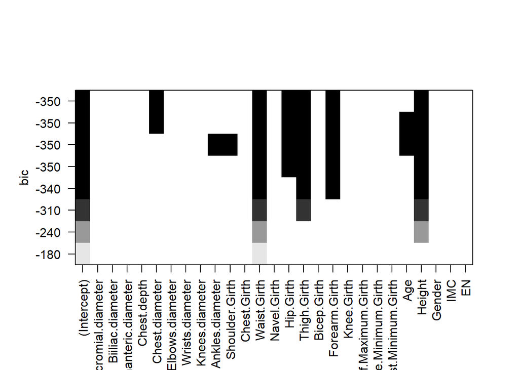

```r
comb <- regsubsets(Weight ~ ., data = muestra, nbest = 1, nvmax = 8, method = "exhaustive", force.out = c("IMC", "EN"))
plot(comb)
```

```r
resumen <- summary(comb)

pos_bic_min <- which.min(resumen$bic)
comb_mejor_bic <- resumen$which[pos_bic_min, ]
var_mejor_bic <- names(comb_mejor_bic)[comb_mejor_bic]
nombre_mejor_bic <- unique(gsub("(.*)\\d$", "\\1", var_mejor_bic))
cat("Nombre del mejor modelo según BIC:\n")
```

```
## Nombre del mejor modelo según BIC:
```

```r
print(nombre_mejor_bic)
```

```
## [1] "(Intercept)"    "Chest.diameter" "Waist.Girth"    "Hip.Girth"
## [5] "Thigh.Girth"    "Forearm.Girth"  "Height"
```

```r
# confección del modelo
mejores_predictores = nombre_mejor_bic[-1]
formula_mejor = as.formula(paste("Weight ~", paste(mejores_predictores, collapse = " + ")))
set.seed(20994)
modelo_tr = train(formula_mejor, data = muestra, method = "lm", trControl = trainControl(method = "boot", number = 100))
modelo_leaps = modelo_tr$finalModel
```

### Confiabilidad de RLM `leaps`

#### 1. La variable de respuesta `Weight` es cuantitativa y continua.

#### 2. Los predictores a utilizar: `Chest.diameter`, `Waist.Girth`, `Hip.Girth`, `Thigh.Girth`, `Forearm.Girth` y `Height`, son variables cuantitativas y continuas.

#### 3. Los predictores previamente mencionados presentan variabilidad.

#### 4. Relación lineal entre predictores y respuesta

```r
set.seed(20994)

rlm_leaps_nuevo <- lm(formula_mejor, muestra)

cat("Prueba de curvatura para predictores")
```

```
## Prueba de curvatura para predictores
```

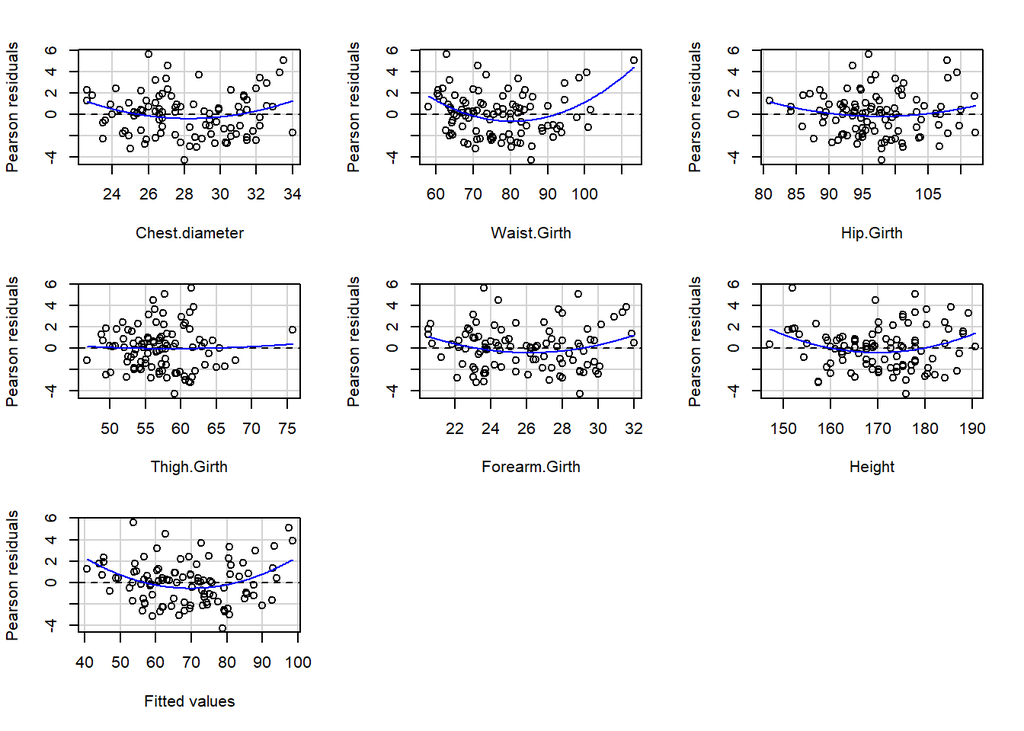

```
##                Test stat Pr(>|Test stat|)
## Chest.diameter    2.1231        0.0364289 *
## Waist.Girth       4.4693        2.232e-05 ***
## Hip.Girth         1.3901        0.1678569
## Thigh.Girth       0.2753        0.7837278
## Forearm.Girth     2.1147        0.0371558 *
## Height            2.4909        0.0145361 *
## Tukey test        3.7596        0.0001702 ***
## ---
## Signif. codes:  0 '***' 0.001 '**' 0.01 '*' 0.05 '.' 0.1 ' ' 1
```

```r
residualPlots(rlm_leaps_nuevo)
```

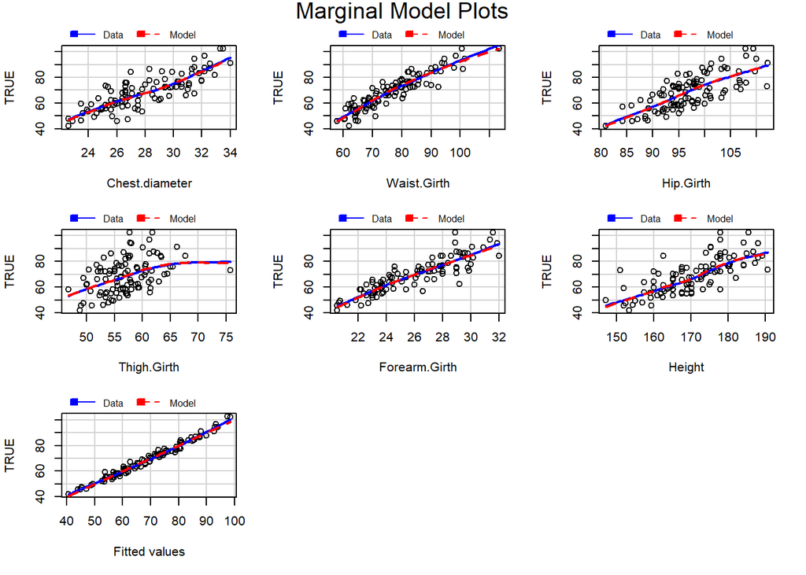

```r
marginalModelPlots(rlm_leaps_nuevo)
```

#### 5. Distribución de residuos debe ser cercana a la normal

```r
normalidad_residuos <- shapiro.test(residuals(rlm_leaps_nuevo))
p_valor_normalidad <- normalidad_residuos$p.value
```

#### 6. La variabilidad de los residuos debe ser aproximadamente constante

```r
variabilidad_residuos <- ncvTest(rlm_leaps_nuevo)
print(variabilidad_residuos)
```

```
## Non-constant Variance Score Test
## Variance formula: ~ fitted.values
## Chisquare = 2.827303, Df = 1, p = 0.092674
```

```r
p_valor_variabilidad <- variabilidad_residuos$p.value
```

#### 7. Residuos independientes

```r
set.seed(20994)
durbinWatsonTest(rlm_leaps_nuevo)
```

```
##  lag Autocorrelation D-W Statistic p-value
##    1      0.07393048      1.849354   0.456
##  Alternative hypothesis: rho != 0
```

En base a la prueba de Durbin-Watson para correlación entre variables, cómo se observa un p-value de $0.456$, fallamos en rechazar la hipótesis nula, por lo tanto se concluye que no tenemos evidencia suficiente para descartar que las observaciones no presenten autocorrelación.

#### 8. Multicolinealidad

```r
set.seed(20994)

cat("Factores de inflación de la varianza:\n")
```

```
## Factores de inflación de la varianza:
```

```r
print(vif(modelo_leaps))
```

```
## Chest.diameter    Waist.Girth      Hip.Girth    Thigh.Girth  Forearm.Girth
##       3.940711       6.241445       8.799757       5.718126       5.585868
##         Height
##       2.743868
```

```r
cat("Valores de tolerancia:\n")
```

```
## Valores de tolerancia:
```

```r
print(1 / vif(modelo_leaps))
```

```
## Chest.diameter    Waist.Girth      Hip.Girth    Thigh.Girth  Forearm.Girth
##      0.2537613      0.1602193      0.1136395      0.1748825      0.1790232
##         Height
##      0.3644490
```

Observando detenidamente los factores de inflación de la varianza, los más problemáticos vendrían a ser, en su respectivo órden: - `Hip.Girth` - `Waist.Girth` - `Thigh Girth` - `Forearm.Girth`

Estos se consideran problematicos ya que el $VIF$ oscila entre 5 y 10 ($5 \leq VIF \leq 10$). Más aún, notar que los valores de tolerancia asociadas a las variables muestran señales de colinealidad entre sí, notando que `Height` y `Chest.diameter` son las únicas variables cuyos valores de tolerancia son mayores que $0.2$. De esto, sabemos que la mayoría de variables asociadas al modelo poseen multicolinealidad preocupante, por lo que los resultados pueden verse significativamente afectados,

#### 9. Las estimaciones de los coeficientes del modelo no debe estar alterados por unos pocas observaciones influyentes.

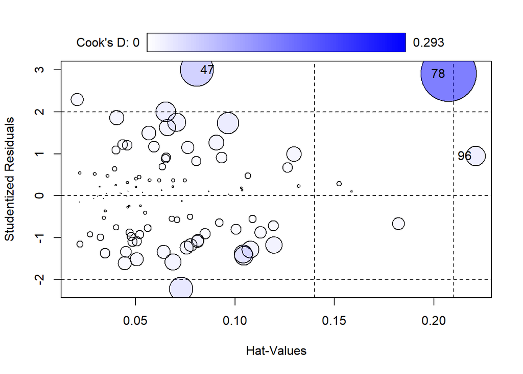

```
##      StudRes        Hat      CookD
## 47 3.0007354 0.08090242 0.10425571
## 78 2.9086962 0.20748066 0.29292335
## 96 0.9465141 0.22088062 0.03632421
```

```r
set.seed(20994)
apalancamiento <- (length(mejores_predictores)+1)/length(muestra)
influencePlot(rlm_leaps_nuevo)
```

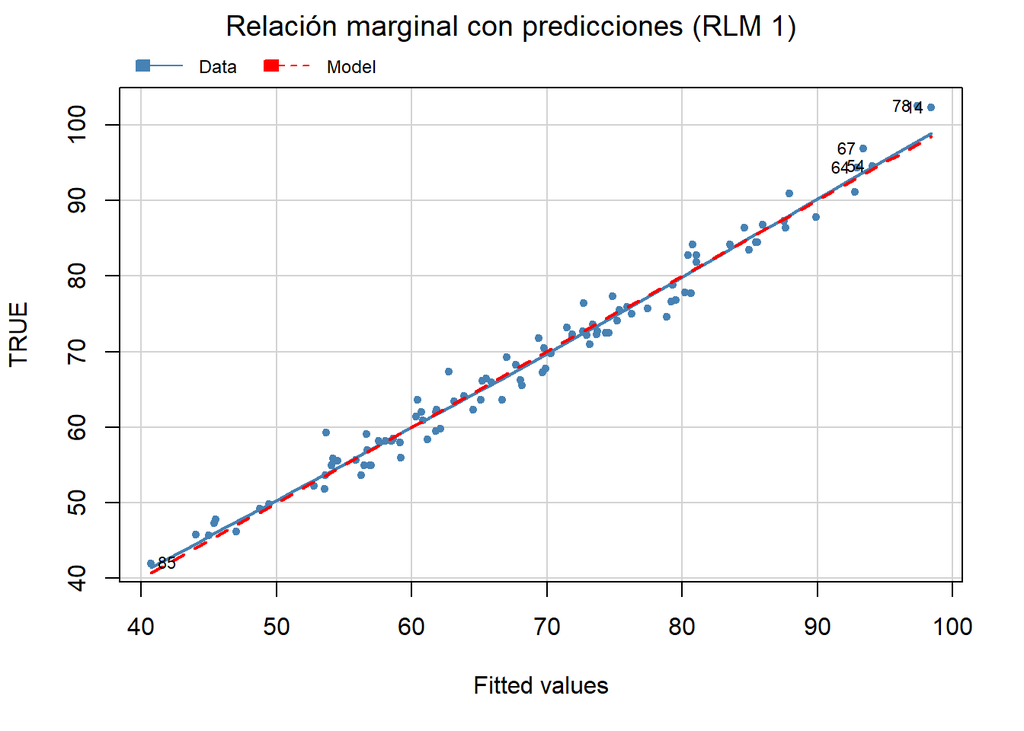

```r
set.seed(20994)
mmps(rlm_leaps_nuevo, terms = ~ 1,
        col = "steelblue", pch = 20, col.line = c("steelblue", "red"),
        smooth = list(smoother = loessLine, span = 1),
        id = list(n = 6, cex = 0.7, location = "lr"),
        main = "Relación marginal con predicciones (RLM 1)", sub = " ")
```

### Poder predictivo del modelo

```r
summary(modelo_leaps)
```

```
##
## Call:
## lm(formula = .outcome ~ ., data = dat)
##
## Residuals:
##     Min      1Q  Median      3Q     Max
## -4.2820 -1.5903  0.0976  1.0624  5.6341
##
## Coefficients:
##                  Estimate Std. Error t value Pr(>|t|)
## (Intercept)    -114.71045    5.04976 -22.716  < 2e-16 ***
## Chest.diameter    0.43217    0.14320   3.018  0.00328 **
## Waist.Girth       0.47569    0.04531  10.499  < 2e-16 ***
## Hip.Girth         0.29670    0.09354   3.172  0.00205 **
## Thigh.Girth       0.34916    0.10582   3.299  0.00137 **
## Forearm.Girth     0.88946    0.16426   5.415 4.77e-07 ***
## Height            0.37083    0.03499  10.599  < 2e-16 ***
## ---
## Signif. codes:  0 '***' 0.001 '**' 0.01 '*' 0.05 '.' 0.1 ' ' 1
##
## Residual standard error: 2.041 on 93 degrees of freedom
## Multiple R-squared:  0.9781, Adjusted R-squared:  0.9767
## F-statistic: 691.7 on 6 and 93 DF,  p-value: < 2.2e-16
```

```r
cat("Poder Predictivo del Modelo (evaluado con Bootstrapping): \n")
```

```
## Poder Predictivo del Modelo (evaluado con Bootstrapping):
```

```r
print(modelo_tr)
```

```
## Linear Regression
##
## 100 samples
##   6 predictor
##
## No pre-processing
## Resampling: Bootstrapped (100 reps)
## Summary of sample sizes: 100, 100, 100, 100, 100, 100, ...
## Resampling results:
##
##   RMSE      Rsquared   MAE
##   2.229488  0.9730712  1.768302
##
## Tuning parameter 'intercept' was held constant at a value of TRUE
```

Del entrenamiento obtenido por medio de bootstraping, se obtuvieron las siguientes métricas:

- $RMSE = 2.229488$, esto implica que, en promedio, tiene un error medio de $2,2 [kg]$
- $R^2 = 0.9730712$, indica que puede explicar un $97,31\%$ de la variabilidad del peso de una persona.

## Regresión Lineal Múltiple con `caret`

> Haciendo un poco de investigación sobre el paquete caret, en particular cómo hacer Recursive Feature Elimination (RFE), construir un modelo de regresión lineal múltiple para predecir la variable IMC que incluya entre 10 y 20 predictores, seleccionando el conjunto de variables que maximice R2 y que use cinco repeticiones de validación cruzada de cinco pliegues para evitar el sobreajuste (obviamente no se debe considerar las variables Peso, Estatura ni estado nutricional –Weight, Height, EN respectivamente).

Para el paquete `caret`, existen dos implementaciones de RFE.

**La primera implementación tiene la siguiente secuencia de pasos:**

```
ALGORITMO 1
1.  entrenar el modelo utilizando todos los predictores
2.  calcular el rendimiento del modelo
3.  calcular la importancia de cada variable
4.  para cada subconjunto de tamaño S_i, i = 1...S:
5.      mantener el S_i cuyas variables tengan mayor importancia
6.      entrenar el modelo con los predictores en S_i
7.      calcular el rendimiento del modelo
8.  fin
9.  calcular el perfil de rendimiento por sobre S_i
10. determinar la cantidad apropiada de predictores
11. usar el modelo correspondiente al S_i óptimo
```

El algoritmo tiene un enfoque iterativo por sobre los $S_i$ mejores predictores candidatos, luego se va evaluando con cada entrenamiento del modelo con las nuevas mejores predictores el rendimiento del nuevo modelo hasta agotar todas las $i: 1, \dots , S$ posibles variables. La implementación en cuestión se invoca con `rfeIter``.

Ahora, la segunda implementación proviene de un algoritmo con un enfoque de remuestreo, cómo fué previamente visto el remuestreo (cómo lo puede ser bootstrap o validación cruzada) permite tomar en cuenta la variabilidad del modelo, por lo que algoritmo 2 sigue la siguiente secuencia de pasos:

```
ALGORITMO 2
1.   para cada itereación de remuestreo:
2.      particionar los datos en conjunto de entrenamiento y prueba
3.      entrenar el modelo utilizando todos los predictores
4.      predecir las muestras del conjunto de prueba
5.      calcular la importancia de cada variable
6.      para cada subconjunto de tamaño S_i, i = 1...S:
7.          mantener el S_i cuyas variables tengan mayor importancia
8.          entrenar el modelo con los predictores en S_i
9.          predecir con la muestra de prueba
10.     fin
11.  fin
12.  calcular el perfil de rendimiento por sobre S_i usando el conjunto de prueba
13.  determinar la cantidad apropiada de predictores
14.  estimar la lista final de de predictores a mantener en el modelo final
14.  ajustar el modelo basandose en S_i optimo usando el conjunto de entrenamiento original.
```

Esencialmente, es el algoritmo 1 con una “máscara” de remuestreo. Esta implementación se puede invocar por medio de `rfe()`, donde:

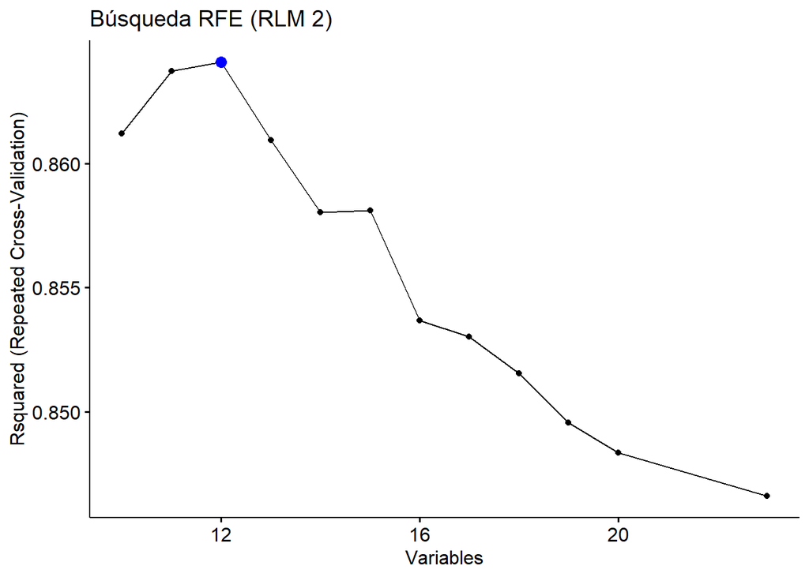

```r
# modelo rlm
set.seed(20994)
datos <- rbind(sobrepeso, no_sobrepeso)
datos<- datos[sample(1:nrow(datos)), ]
#combinaciones <- regsubsets(IMC ~ ., data = datos, nbest=1, nvmax = 20, method = "exhaustive", #force.out=c("Weight", "Height", "EN"))

#resumen_combinaciones <- summary(combinaciones)
#i_r2a_maximo <- which.max(resumen_combinaciones[["adjr2"]])
#mejor_comb_r2a <- resumen_combinaciones[["which"]][i_r2a_maximo, ]
#comb_mejor_r2a <- names(mejor_comb_r2a[mejor_comb_r2a == TRUE])
#nombres_mejor_r2a <- unique(gsub("7(.*)\\d$", "\\1i", comb_mejor_r2a))
#pred_mejor_r2a <- paste(nombres_mejor_r2a[-1], collapse = " + ")
#fmla_mejor_r2a <- as.formula(paste("IMC", pred_mejor_r2a, sep = " ~ "))
#modelo_mejor_r2a <- rfe(form = fmla_mejor_r2a, data = datos)

rfe_control <- rfeControl(functions = lmFuncs,
                          method = "repeatedcv",
                          number = 5,
                          repeats = 5,
                          verbose = FALSE)

modelo_rfe <- rfe(form = IMC ~ . - Height - Weight - EN, data = datos, sizes = 10:20, metric = "Rsquared", maximize = TRUE, rfeControl = rfe_control)

Graficorfe <- ggplot(modelo_rfe) + theme_pubr()
Graficorfe <- ggpar(Graficorfe, title = "Búsqueda RFE (RLM 2)")
print(Graficorfe)
```

```r
RLM_caret<-modelo_rfe$fit
print(modelo_rfe)
```

```
##
## Recursive feature selection
##
## Outer resampling method: Cross-Validated (5 fold, repeated 5 times)
##
## Resampling performance over subset size:
##
##  Variables  RMSE Rsquared    MAE RMSESD RsquaredSD  MAESD Selected
##         10 1.195   0.8612 0.9636 0.2083    0.07173 0.1642
##         11 1.189   0.8637 0.9666 0.1957    0.06882 0.1512
##         12 1.182   0.8641 0.9595 0.2028    0.07129 0.1619        *
##         13 1.196   0.8609 0.9713 0.2058    0.07244 0.1627
##         14 1.208   0.8580 0.9834 0.2103    0.07491 0.1706
##         15 1.207   0.8581 0.9823 0.2076    0.07535 0.1665
##         16 1.227   0.8537 0.9948 0.2005    0.07588 0.1631
##         17 1.230   0.8530 0.9954 0.1977    0.07507 0.1593
##         18 1.238   0.8516 1.0024 0.1964    0.07495 0.1546
##         19 1.247   0.8496 1.0108 0.1987    0.07412 0.1565
##         20 1.253   0.8484 1.0139 0.1979    0.07383 0.1543
##         23 1.263   0.8466 1.0250 0.1985    0.07377 0.1549
##
## The top 5 variables (out of 12):
##    Gender, Knees.diameter, Thigh.Girth, Biiliac.diameter, Elbows.diameter
```

```r
predictores<-predictors(modelo_rfe)
print(predictores)
```

```
##  [1] "Gender"              "Knees.diameter"      "Thigh.Girth"
##  [4] "Biiliac.diameter"    "Elbows.diameter"     "Forearm.Girth"
##  [7] "Waist.Girth"         "Chest.diameter"      "Wrists.diameter"
## [10] "Ankle.Minimum.Girth" "Biacromial.diameter" "Wrist.Minimum.Girth"
```

```r
predictores_concat <- paste(predictores, collapse = " + ")
formula_str <- paste("IMC ~", predictores_concat)
formularfl <- as.formula(formula_str)
```

Del grafico anterior se puede concluir que el modelo que maximiza el $R^{2}$, este utiliza 12 predictores

- Gender
- Knees.diameter
- Thigh.Girth
- Biiliac.diameter
- Elbows.diameter
- Forearm.Girth
- Waist.Girth
- Chest.diameter
- Wrists.diameter
- Ankle.Minimum.Girth
- Biacromial.diameter
- Wrist.Minimum.Girth

Dando como resultado el siguiente modelo:

```r
set.seed(20994)
RLMf<-lm( formularfl , data = datos)
summary(RLMf)
```

```
##
## Call:
## lm(formula = formularfl, data = datos)
##
## Residuals:
##     Min      1Q  Median      3Q     Max
## -2.5357 -0.7110 -0.0574  0.5916  3.3190
##
## Coefficients:
##                     Estimate Std. Error t value Pr(>|t|)
## (Intercept)         -4.97590    2.64407  -1.882 0.063192 .
## Gender              -1.06446    0.59081  -1.802 0.075055 .
## Knees.diameter       0.25717    0.13705   1.877 0.063932 .
## Thigh.Girth          0.23105    0.04037   5.723 1.46e-07 ***
## Biiliac.diameter    -0.25802    0.06762  -3.816 0.000254 ***
## Elbows.diameter     -0.28326    0.18595  -1.523 0.131296
## Forearm.Girth        0.19160    0.12619   1.518 0.132555
## Waist.Girth          0.19341    0.01962   9.858 7.89e-16 ***
## Chest.diameter       0.23283    0.07720   3.016 0.003357 **
## Wrists.diameter      0.11193    0.22352   0.501 0.617792
## Ankle.Minimum.Girth  0.08394    0.09697   0.866 0.389097
## Biacromial.diameter -0.16745    0.06812  -2.458 0.015951 *
## Wrist.Minimum.Girth -0.05533    0.21740  -0.255 0.799695
## ---
## Signif. codes:  0 '***' 0.001 '**' 0.01 '*' 0.05 '.' 0.1 ' ' 1
##
## Residual standard error: 1.018 on 87 degrees of freedom
## Multiple R-squared:  0.9124, Adjusted R-squared:  0.9003
## F-statistic: 75.52 on 12 and 87 DF,  p-value: < 2.2e-16
```

Para continuar, se verificara la confiabilidad del modelo.

### Confiabilidad del RLM optimizando $R^{2}$

#### 1) La variable de respuesta `IMC` es cuantitativa y continua.

Se cumple, ya que el IMC es una variable cuantitativa y continua.

#### 2) Los predictores son variables cuantitativas o dicotomicas

Se cumple debido a que la mayoria son medidas en centimetros y la variable gender es dicotomica

#### 3) Los predictores presentan grado de variabilidad

```r
cat("Variabilidad Gender: ",var(datos$Gender),"\n")
```

```
## Variabilidad Gender:  0.2521212
```

```r
cat("Variabilidad Knees.diameter: ",var(datos$Knees.diameter),"\n")
```

```
## Variabilidad Knees.diameter:  1.738258
```

```r
cat("Variabilidad Thigh.Girth: ",var(datos$Thigh.Girth),"\n")
```

```
## Variabilidad Thigh.Girth:  21.48527
```

```r
cat("Variabilidad Biiliac.diameter: ",var(datos$Biiliac.diameter),"\n")
```

```
## Variabilidad Biiliac.diameter:  3.555203
```

```r
cat("Variabilidad Elbows.diameter: ",var(datos$Elbows.diameter),"\n")
```

```
## Variabilidad Elbows.diameter:  2.045681
```

```r
cat("Variabilidad Forearm.Girth: ",var(datos$Forearm.Girth),"\n")
```

```
## Variabilidad Forearm.Girth:  8.711591
```

```r
cat("Variabilidad Waist.Girth: ",var(datos$Waist.Girth),"\n")
```

```
## Variabilidad Waist.Girth:  127.9234
```

```r
cat("Variabilidad Chest.diameter: ",var(datos$Chest.diameter),"\n")
```

```
## Variabilidad Chest.diameter:  8.086193
```

```r
cat("Variabilidad Wrists.diameter: ",var(datos$Wrists.diameter),"\n")
```

```
## Variabilidad Wrists.diameter:  1.035736
```

```r
cat("Variabilidad Ankle.Minimum.Girth: ",var(datos$Ankle.Minimum.Girth),"\n")
```

```
## Variabilidad Ankle.Minimum.Girth:  3.696334
```

```r
cat("Variabilidad Biacromial.diameter: ",var(datos$Biacromial.diameter),"\n")
```

```
## Variabilidad Biacromial.diameter:  8.859798
```

```r
cat("Variabilidad Wrist.Minimum.Girth: ",var(datos$Wrist.Minimum.Girth),"\n")
```

```
## Variabilidad Wrist.Minimum.Girth:  2.178031
```

Como se puede ver, ninguna varianza es igual a 0, por lo tanto esta condicion se cumple

Ahora se generaran los graficos para las condiciones 4 a 6

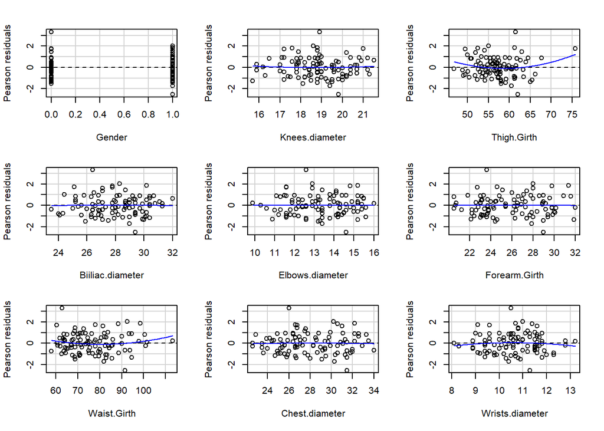

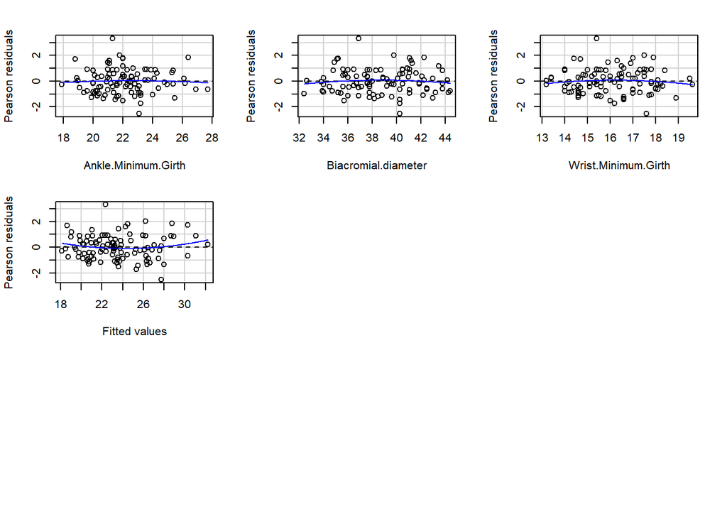

```
##                     Test stat Pr(>|Test stat|)
## Gender                 0.2777          0.78194
## Knees.diameter         0.3578          0.72139
## Thigh.Girth            1.9491          0.05454 .
## Biiliac.diameter      -0.1035          0.91784
## Elbows.diameter       -0.0188          0.98501
## Forearm.Girth         -0.0715          0.94320
## Waist.Girth            1.3890          0.16841
## Chest.diameter        -0.1619          0.87173
## Wrists.diameter       -0.6904          0.49182
## Ankle.Minimum.Girth   -0.3445          0.73131
## Biacromial.diameter   -0.7044          0.48312
## Wrist.Minimum.Girth   -0.8018          0.42489
## Tukey test             1.3868          0.16550
## ---
## Signif. codes:  0 '***' 0.001 '**' 0.01 '*' 0.05 '.' 0.1 ' ' 1
```

```r
set.seed(20994)
residualPlots(RLMf)
```

```r
cat("\n")
```

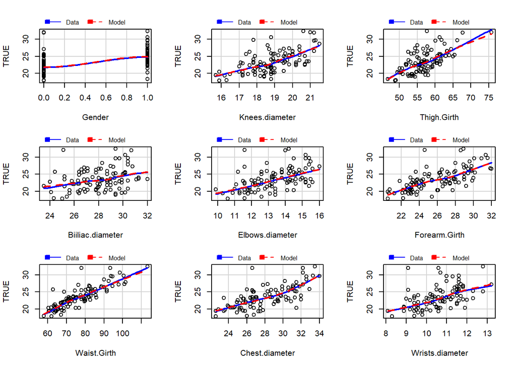

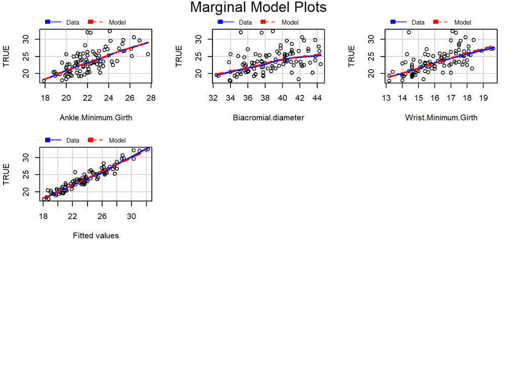

```r
marginalModelPlots(RLMf)
```

```r
ncvTest(RLMf)
```

```
## Non-constant Variance Score Test
## Variance formula: ~ fitted.values
## Chisquare = 2.531694, Df = 1, p = 0.11158
```

#### 5) Distribucion normal de residuos

```r
set.seed(20994)
residuos<-resid(RLMf)
#media muy cercana a 0
print(mean(residuos))
```

```
## [1] 1.934921e-17
```

```r
#test de normalidad
#P-value mayor a 0.05m permitiendo concluir que no existe evidencia suficiente para rechazar que lo residuos no tengan una disribucion normal
print(shapiro.test(residuos))
```

```
##
##  Shapiro-Wilk normality test
##
## data:  residuos
## W = 0.98381, p-value = 0.2599
```

Primero que nada, la media de los residuos es muy cercana a 0 ($1.934921*10^{-17}$), ademas el test de Shapiro-Wilk da un resultado de $p-value=0.2599 > 0.05$, por lo tanto no se tiene evidencia suficiente para rechazar la condicion de normalidad de los residuos.

#### 7) Independencia de residuos.

```r
print(durbinWatsonTest(RLMf))
```

```
##  lag Autocorrelation D-W Statistic p-value
##    1      -0.0218808      2.037268   0.762
##  Alternative hypothesis: rho != 0
```

Tambien se obtiene un p-value mayor a 0.05 por lo tanto se puede concluir que se cumple la condicion de la independencia de los residuos.

#### 8) No debe existir multicolinealidad

```r
#existen 4 variables con VIF mayor a 5, por lo tanto se puede concluir que existe multicolinealidad alarmante entre las variables
cat("Factores de Inflación de la Varianza:\n")
```

```
## Factores de Inflación de la Varianza:
```

```r
print(vif(RLMf))
```

```
##              Gender      Knees.diameter         Thigh.Girth    Biiliac.diameter
##            8.413829            3.121334            3.348284            1.554338
##     Elbows.diameter       Forearm.Girth         Waist.Girth      Chest.diameter
##            6.762485           13.263136            4.707921            4.607469
##     Wrists.diameter Ankle.Minimum.Girth Biacromial.diameter Wrist.Minimum.Girth
##            4.947321            3.323065            3.930976            9.841798
```

```r
cat("\nValores de Tolerancia:\n")
```

```
##
## Valores de Tolerancia:
```

```r
print(1/vif(RLMf))
```

```
##              Gender      Knees.diameter         Thigh.Girth    Biiliac.diameter
##          0.11885195          0.32037581          0.29866041          0.64336057
##     Elbows.diameter       Forearm.Girth         Waist.Girth      Chest.diameter
##          0.14787464          0.07539695          0.21240798          0.21703891
##     Wrists.diameter Ankle.Minimum.Girth Biacromial.diameter Wrist.Minimum.Girth
##          0.20212958          0.30092696          0.25438976          0.10160745
```

De los resultados anteeriores se encuentran varios predictores con un $VIF$ mayor a 5, lo que indica que existe multicolinealidad entre las variables, mas importantemente, el $VIF$ de Forearm.Girth es mayor a 10, demostrando una multicolinealidad extremadamente alta.

#### 9)Las estimaciones de los coeficientes del modelo no debe estar alterados por unos pocas observaciones influyentes.

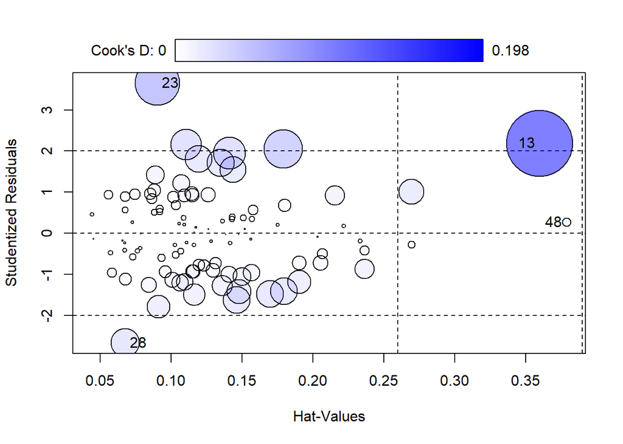

```
##       StudRes        Hat       CookD
## 13  2.1855085 0.35999595 0.198071790
## 28 -2.6699531 0.06760096 0.037140768
## 48  0.2681574 0.37890801 0.003410923
## 23  3.6543272 0.09022239 0.089203933
```

```r
influencePlot(RLMf)
```

```r
#Distancias de cook muy bajas
```

En todos los casos anteriores se obtiene una distancia de Cook muy baja, por lo tanto no se se tiene la evidencia suficiente para rechazar el cumplimiento de la condicion.

De los resultados anteriores, hay varios factores que ponen en duda la confiabilidad del modelo, por lo que se procedera a analizar que variables eliminar

## Predictores Problematicos:

Se procede a eliminar los 2 predictores con mayor $VIF$ (Forearm.Girth y Wrist.Minimum.Girth)

```r
nueva_formula <- update(formularfl, . ~ . - Forearm.Girth - Wrist.Minimum.Girth)
print(nueva_formula)
```

```
## IMC ~ Gender + Knees.diameter + Thigh.Girth + Biiliac.diameter +
##     Elbows.diameter + Waist.Girth + Chest.diameter + Wrists.diameter +
##     Ankle.Minimum.Girth + Biacromial.diameter
```

```r
RLMf2 <- lm(nueva_formula, data = datos)
summary(RLMf2)
```

```
##
## Call:
## lm(formula = nueva_formula, data = datos)
##
## Residuals:
##     Min      1Q  Median      3Q     Max
## -2.6577 -0.7069 -0.0426  0.6006  3.1958
##
## Coefficients:
##                     Estimate Std. Error t value Pr(>|t|)
## (Intercept)         -4.61793    2.60362  -1.774 0.079540 .
## Gender              -0.60786    0.51661  -1.177 0.242476
## Knees.diameter       0.23542    0.13630   1.727 0.087600 .
## Thigh.Girth          0.25917    0.03614   7.171 2.11e-10 ***
## Biiliac.diameter    -0.27010    0.06683  -4.042 0.000112 ***
## Elbows.diameter     -0.15034    0.16611  -0.905 0.367854
## Waist.Girth          0.19726    0.01903  10.368  < 2e-16 ***
## Chest.diameter       0.25467    0.07512   3.390 0.001044 **
## Wrists.diameter      0.08268    0.20674   0.400 0.690164
## Ankle.Minimum.Girth  0.08701    0.09399   0.926 0.357099
## Biacromial.diameter -0.16222    0.06813  -2.381 0.019390 *
## ---
## Signif. codes:  0 '***' 0.001 '**' 0.01 '*' 0.05 '.' 0.1 ' ' 1
##
## Residual standard error: 1.021 on 89 degrees of freedom
## Multiple R-squared:  0.9098, Adjusted R-squared:  0.8997
## F-statistic: 89.82 on 10 and 89 DF,  p-value: < 2.2e-16
```

Se continua con el grafico de residuos

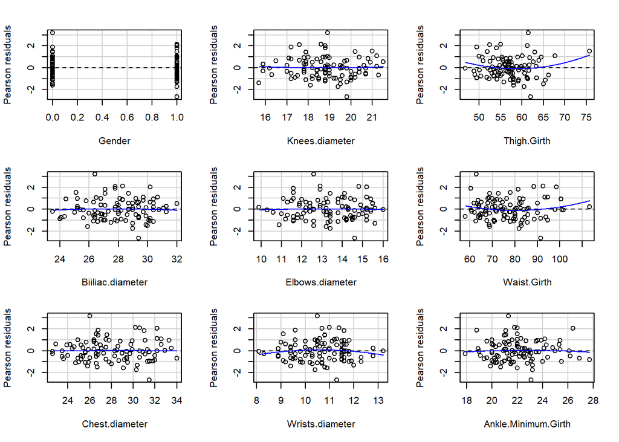

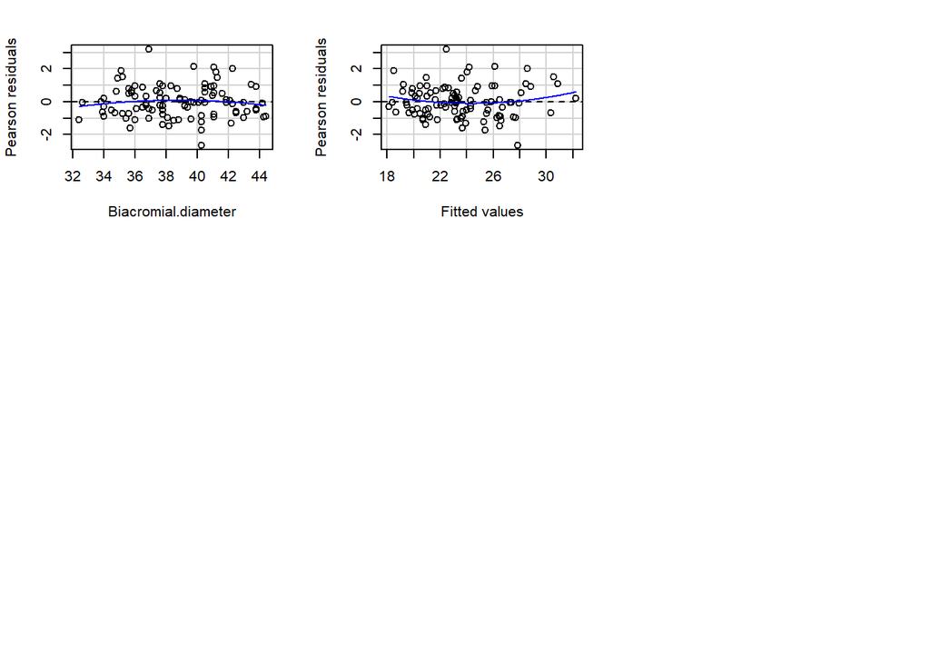

```
##                     Test stat Pr(>|Test stat|)
## Gender                 0.2650          0.79163
## Knees.diameter         0.2679          0.78943
## Thigh.Girth            1.8434          0.06863 .
## Biiliac.diameter      -0.2991          0.76557
## Elbows.diameter       -0.1721          0.86378
## Waist.Girth            1.5228          0.13140
## Chest.diameter        -0.0537          0.95731
## Wrists.diameter       -0.9885          0.32560
## Ankle.Minimum.Girth   -0.3378          0.73629
## Biacromial.diameter   -0.8968          0.37227
## Tukey test             1.4153          0.15699
## ---
## Signif. codes:  0 '***' 0.001 '**' 0.01 '*' 0.05 '.' 0.1 ' ' 1
```

```r
residualPlots(RLMf2)
```

```r
cat("\n")
```

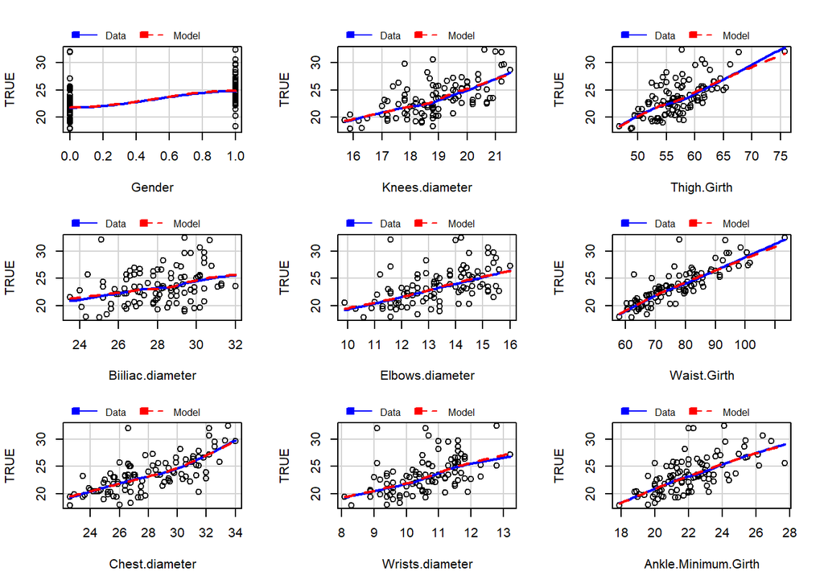

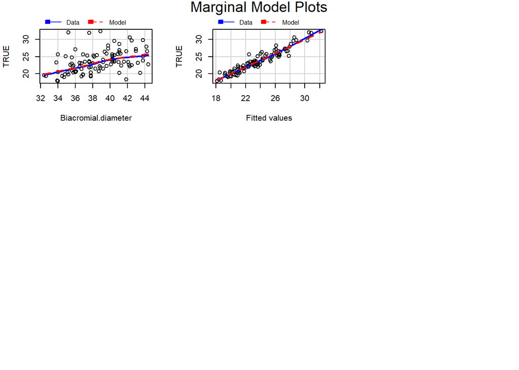

```r
marginalModelPlots(RLMf2)
```

```r
ncvTest(RLMf2)
```

```
## Non-constant Variance Score Test
## Variance formula: ~ fitted.values
## Chisquare = 2.958293, Df = 1, p = 0.085438
```